# GLM Practice

Uzezi Okinedo

11/23/2020

```r
# load libraries
library(ggplot2)
library(Rmisc)
library(dplyr)
library(modelr)
library(emmeans)
library(piecewiseSEM)
library(car)
library(tidyverse)
library(doBy)
library(ggpubr)
library(MASS)
library(profileModel)
library(broom.mixed)
library(brms)
library(tidybayes)
library(boot)
library(ggdist)
library(loo)
library(modelr)
```

**1. Comparing Means**

To start with, let’s warm up with a simple one-way ANOVA model. This example, from Whitlock and Schluter chapter 15 question 22 looks at the mass of lodgepole pinecones from different habitats.

**1.1.** Load and plot the data. Choose a plot that not only shows the raw data, but also the means and SE or CI of those means. +1 EC if Michael thinks it’s fancy.

```r
#load data
lodgepole <- read.csv("./raw_data/all_data/chapter15/chap15q23LodgepolePineCones.csv")

# view data
head(lodgepole)
```

```
##         habitat conemass
## 1 island.absent      9.6
## 2 island.absent      9.4
## 3 island.absent      8.9
## 4 island.absent      8.8
## 5 island.absent      8.5
## 6 island.absent      8.2
```

```r
# summarize mean, sd, se and ci of data using Rmisc::summarySE function
lodgepole2 <- summarySE(lodgepole, measurevar="conemass", groupvars="habitat")

# view summary table
lodgepole2
```

```
##            habitat N conemass        sd        se        ci
## 1    island.absent 6     8.90 0.5291503 0.2160247 0.5553091
## 2   island.present 5     6.08 0.6220932 0.2782086 0.7724308
## 3 mainland.present 5     6.12 0.4658326 0.2083267 0.5784076
```

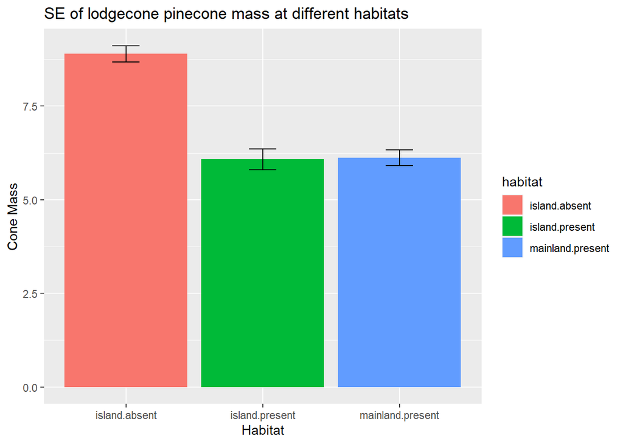

```r
# plot
# Error bars represent standard error of the mean
ggplot(lodgepole2, aes(y=conemass, x=factor(habitat), fill =habitat)) +
    geom_bar(position=position_dodge(), stat="identity") +
    geom_errorbar(aes(ymin=conemass-se, ymax=conemass+se),
                  width=.2,                    # Width of the error bars
                  position=position_dodge(.9)) +
  labs(y ="Cone Mass", x = "Habitat",
       title = "SE of lodgecone pinecone mass at different habitats")
```

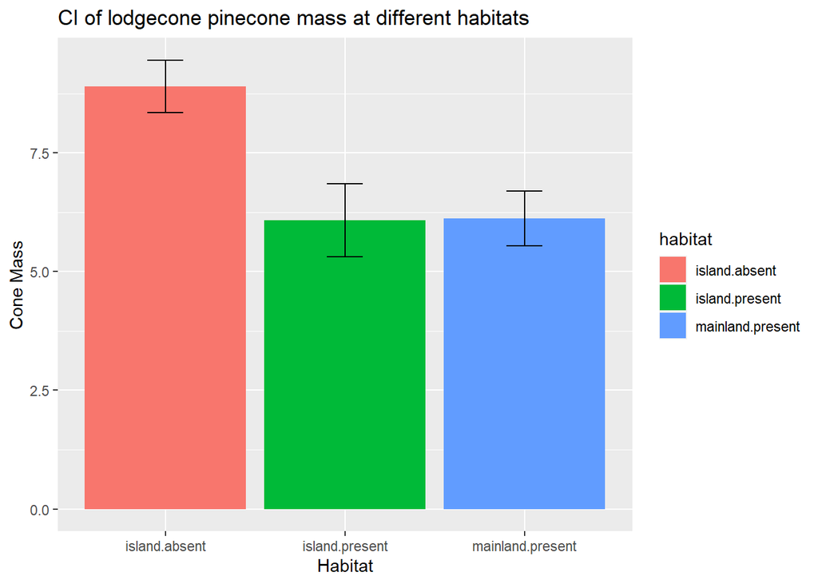

```r
# Use 95% confidence intervals instead of SEM
ggplot(lodgepole2, aes(y=conemass, x=factor(habitat), fill =habitat)) +
    geom_bar(position=position_dodge(), stat="identity") +
    geom_errorbar(aes(ymin=conemass-ci, ymax=conemass+ci),
                  width=.2,                    # Width of the error bars
                  position=position_dodge(.9)) +
  labs(y ="Cone Mass", x = "Habitat",
       title = "CI of lodgecone pinecone mass at different habitats")
```

**1.2** Fit a model using least squares and evaluate all relevant assumptions. List them out as you test them. Can we use this model? If not, fix it. But if we can, no fix is needed!

```
## No summary function supplied, defaulting to `mean_se()`
```

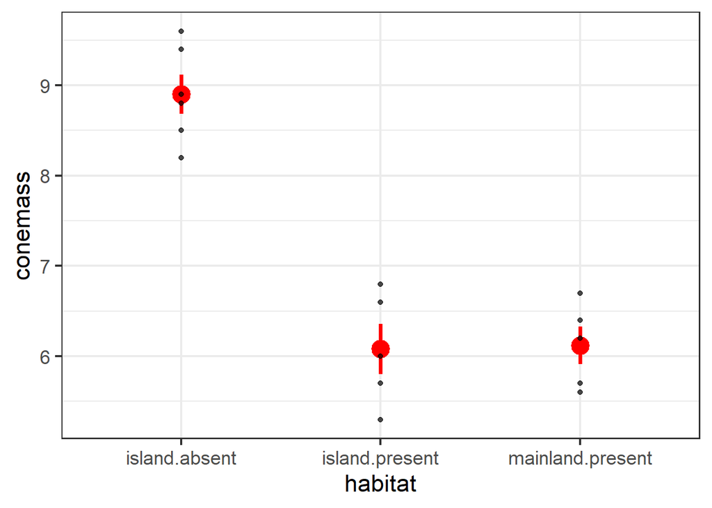

```r
#exploring the data
ggplot(lodgepole, mapping=aes(x=habitat, y=conemass)) +
  stat_summary(color="red", size=1.3) +
    geom_point(alpha=0.7) +
  theme_bw(base_size=17)
```

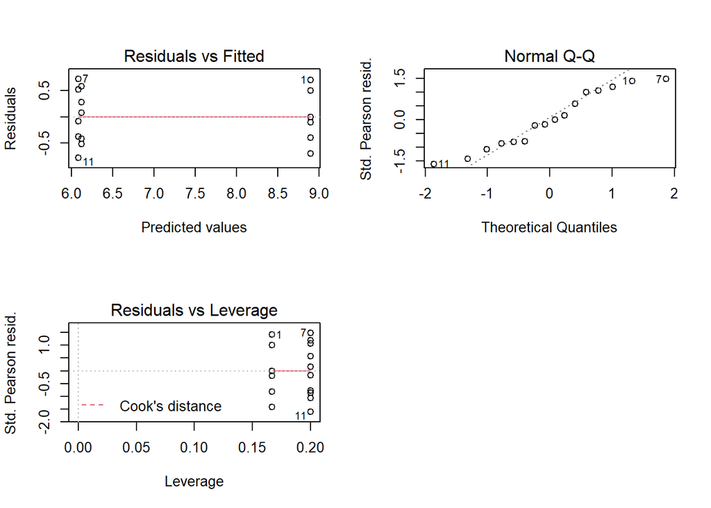

```r
# fit a model
lodgepole_glm <- glm(conemass ~ factor(habitat),
                 data = lodgepole,
                 family = gaussian(link = "identity"))


# assumptions evaluation
#The whole par thing lets me make a multi-panel plot
par(mfrow=c(2,2))
plot(lodgepole_glm, which=c(1,2,5))
par(mfrow=c(1,1))
```

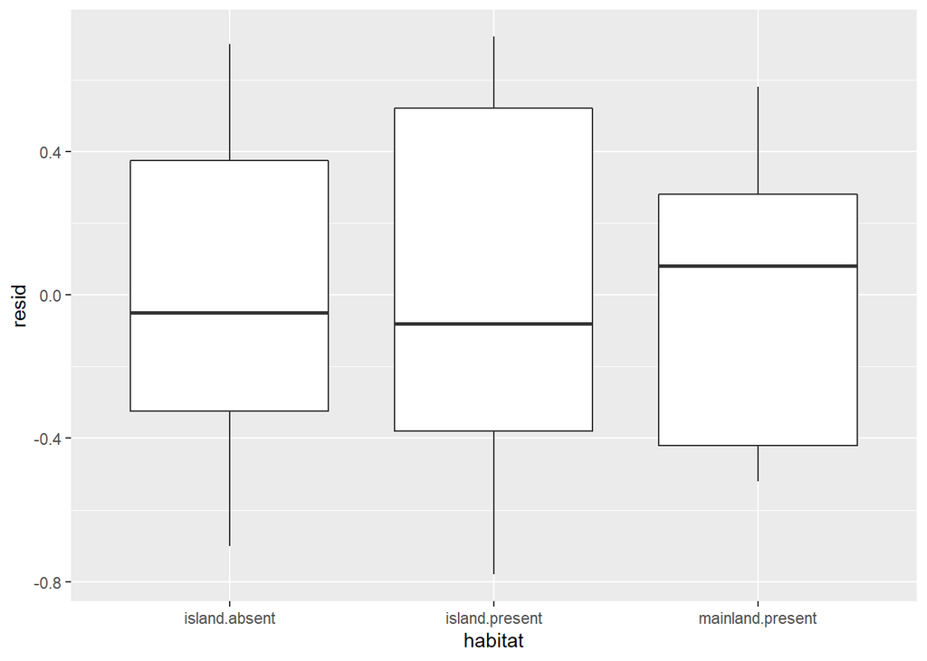

```r
# compare the distribution of residuals across each habitat
lodgepole <- lodgepole %>%
  add_residuals(lodgepole_glm)

qplot(habitat, resid, data = lodgepole, geom = "boxplot")
```

```r
# F-test
Anova(lodgepole_glm)
```

```
## Analysis of Deviance Table (Type II tests)
##
## Response: conemass
##                 LR Chisq Df Pr(>Chisq)
## factor(habitat)   100.17  2  < 2.2e-16 ***
## ---
## Signif. codes:  0 '***' 0.001 '**' 0.01 '*' 0.05 '.' 0.1 ' ' 1
```

```r
#post-hocs tests
lodgepole_em <- emmeans::emmeans(lodgepole_glm, specs = ~ habitat)
lodgepole_em
```

```
##  habitat          emmean    SE  df asymp.LCL asymp.UCL
##  island.absent      8.90 0.221 Inf      8.47      9.33
##  island.present     6.08 0.242 Inf      5.61      6.55
##  mainland.present   6.12 0.242 Inf      5.65      6.59
##
## Confidence level used: 0.95
```

```r
# contrast means
contrast(lodgepole_em, method = "tukey")
```

```
##  contrast                          estimate    SE  df z.ratio p.value
##  island.absent - island.present        2.82 0.328 Inf  8.596  <.0001
##  island.absent - mainland.present      2.78 0.328 Inf  8.474  <.0001
##  island.present - mainland.present    -0.04 0.343 Inf -0.117  0.9925
##
## P value adjustment: tukey method for comparing a family of 3 estimates
```

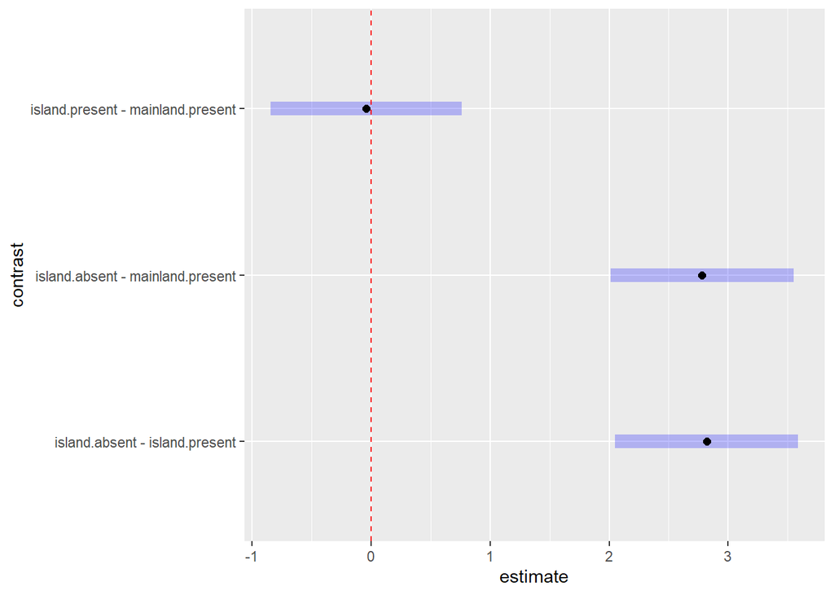

```r
# plot contrasts
plot(contrast(lodgepole_em,
        method = "tukey")) +
  geom_vline(xintercept = 0, color = "red", lty=2)
```

```r
# see which groups are statistically the same versus different using cld
multcomp::cld(lodgepole_em, adjust="tukey")
```

```
## Note: adjust = "tukey" was changed to "sidak"
## because "tukey" is only appropriate for one set of pairwise comparisons
```

```
##  habitat          emmean    SE  df asymp.LCL asymp.UCL .group
##  island.present     6.08 0.242 Inf      5.50      6.66  1
##  mainland.present   6.12 0.242 Inf      5.54      6.70  1
##  island.absent      8.90 0.221 Inf      8.37      9.43   2
##
## Confidence level used: 0.95
## Conf-level adjustment: sidak method for 3 estimates
## P value adjustment: tukey method for comparing a family of 3 estimates
## significance level used: alpha = 0.05
```

```
## Note: adjust = "tukey" was changed to "sidak"
## because "tukey" is only appropriate for one set of pairwise comparisons
```

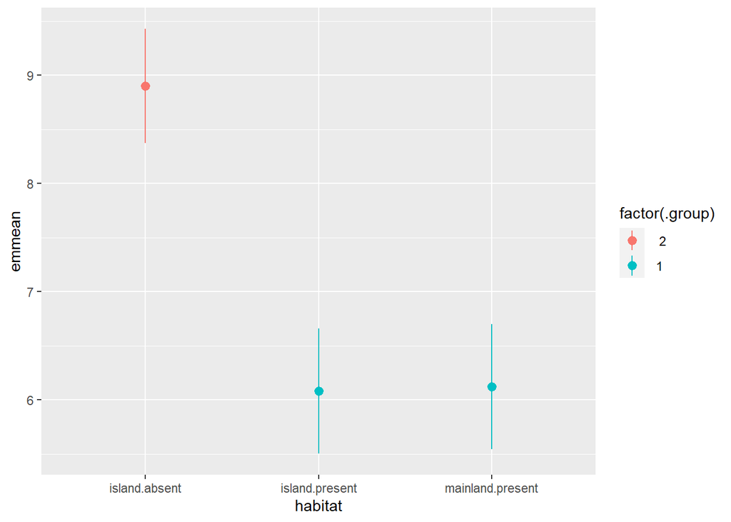

```r
# plot
multcomp::cld(lodgepole_em, adjust="tukey") %>%
  ggplot(aes(x = habitat, y = emmean,
             ymin = asymp.LCL, ymax = asymp.UCL,
             color = factor(.group))) +
  geom_pointrange()
```

**1.2** How much variation is explained by your model?

A significant amount of variation was explained by this model. Out of the three pairwise comparisons, two were significantly different where, p < 0.05

**1.3** Show which means are different from each other. Are you correcting p-values? If so, how, and justify your choice.

Yes, I am correcting p-values for easy detection of statistically significant differences between all pairwise comparisons.

```r
# p-value correction
contrast(lodgepole_em,
        method = "tukey", adjust="bonferroni")
```

```
##  contrast                          estimate    SE  df z.ratio p.value
##  island.absent - island.present        2.82 0.328 Inf  8.596  <.0001
##  island.absent - mainland.present      2.78 0.328 Inf  8.474  <.0001
##  island.present - mainland.present    -0.04 0.343 Inf -0.117  1.0000
##
## P value adjustment: bonferroni method for 3 tests
```

**2. Comparing Means from Multiple Categories**

In a study from Rogers *et al*. (2020) link, the authors performed an experiment where they moved panels that had been colonized by invertebrates on a dock to a nearby rocky jetty where predators could access panels. To separate out the effects of changes in abiotic environment versus predation, they performed a factorial experiment, either caging or not caging panels and placing them either on the side of a cinder block or hanging on a piece of PVC attached to the block where predators would have little access (but weren’t entirely stopped). They then looked at change in total cover of invertebrates. Using this old data file dug off of my hard drive, let’s see what they found.

**2.1.** Load and plot the data. We are interested in change in percent cover. Choose a plot that not only shows the raw data, but also the means and SE or CI of those means. +1 EC if Michael thinks it’s fancy.

```r
# download and read data directly and fix names using janitor::clean_names
fouling <- read.csv("./raw_data/fouling_transplant_data.csv") %>%
  janitor::clean_names()

# view data
head(fouling)
```

```
##   treatment caged position_on_block botry_init botry_fin water_init water_fin
## 1      DJHC Caged           Hanging         13        13          3         3
## 2      DJHC Caged           Hanging         11        11          5         5
## 3      DJHC Caged           Hanging         21        21          7         8
## 4      DJHC Caged           Hanging         24        22         23        21
## 5      DJHC Caged           Hanging         14        12          9         8
## 6      DJHC Caged           Hanging         28        29         13        10
##   diplo_init diplo_fin distap_init distap_fin bugula_init bugula_fin
## 1          0         0           1          1           4          4
## 2         20        25           2          4           2          3
## 3          0         0           0          3           0          0
## 4          0         0           0          0           0          0
## 5          0         0           0          0           2          1
## 6          0         0           1          1           1          1
##   initial_cover final_cover change_in_cover
## 1            21          21               0
## 2            40          48               8
## 3            28          32               4
## 4            47          43              -4
## 5            25          21              -4
## 6            43          41              -2
```

```r
# convert double to factor
fouling2 <- fouling %>%
  mutate_at(vars(botry_init, botry_fin, water_init, water_fin, diplo_init, diplo_fin, distap_init, distap_fin, bugula_init, bugula_fin, initial_cover, final_cover, change_in_cover),
            list(factor)) %>%
  summarise(treatment, caged, position_on_block, change_in_cover)

long_fouling2 <- fouling2 %>%
  pivot_longer(cols = -c(treatment, caged, position_on_block),
               names_to = "variables",
               values_to = "results")

# summarize mean, sd, se and ci of data using Rmisc::summarySE function
sum_fouling <- summaryBy(results ~ treatment + caged + position_on_block, data=long_fouling2, FUN=c(length, mean, sd)) %>%
  mutate(result.se = results.sd / sqrt(results.length)) %>%
  pivot_longer(cols = c("treatment", "caged", "position_on_block"),
               names_to = "conditions")

# view data
head(sum_fouling)
```

```
## # A tibble: 6 x 6
##   results.length results.mean results.sd result.se conditions        value
##            <dbl>        <dbl>      <dbl>     <dbl> <chr>             <chr>
## 1              8        11          4.31      1.52 treatment         DJHC
## 2              8        11          4.31      1.52 caged             Caged
## 3              8        11          4.31      1.52 position_on_block Hanging
## 4              8         9.88       5.25      1.86 treatment         DJHO
## 5              8         9.88       5.25      1.86 caged             Open
## 6              8         9.88       5.25      1.86 position_on_block Hanging
```

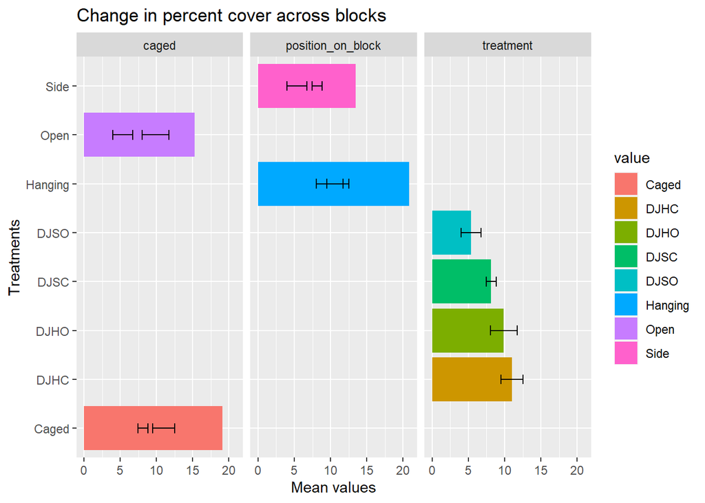

```r
# plot
# Error bars represent standard error of the mean
ggplot(sum_fouling, aes(y=results.mean, x=value, fill =value)) +
  facet_grid(. ~ conditions) +
  geom_bar(stat="identity") +
  geom_errorbar(aes(ymin=results.mean-result.se, ymax=results.mean+result.se),
                  width=.2,                    # Width of the error bars
                  position="identity") +
  coord_flip() +
  labs(y ="Mean values", x = "Treatments",
       title = "Change in percent cover across blocks")
```

**2.2** Fit a model using likelihood and evaluate all relevant assumptions. Do you meet assumptions?

```r
# Factorial Anova

# fit and assumption evaluation
fouling_mle <- glm(change_in_cover ~ position_on_block*caged, data=fouling2, family="binomial")


#The whole par thing lets me make a multi-panel plot
par(mfrow=c(2,2))
plot(fouling_mle, which=c(1,2,5))
```

```
## hat values (leverages) are all = 0.125
##  and there are no factor predictors; no plot no. 5
```

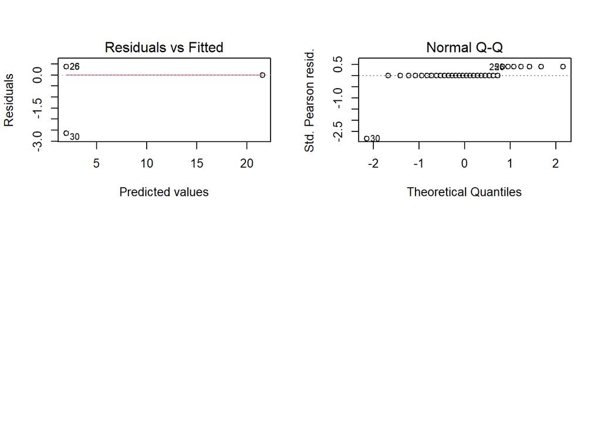

```r
par(mfrow=c(1,1))
```

```r
# compare the distribution of residuals across each habitat
fouling2 <- fouling2 %>%
  add_residuals(fouling_mle)
```

[figure not shown]

```r
qplot(position_on_block, resid, data = fouling2, geom = "boxplot")
```

```r
# F-tests
Anova(fouling_mle)
```

```
## Analysis of Deviance Table (Type II tests)
##
## Response: change_in_cover
##                         LR Chisq Df Pr(>Chisq)
## position_on_block          1.453  1     0.2280
## caged                      1.453  1     0.2280
## position_on_block:caged    0.000  1     0.9999
```

```r
# compare means
fouling_mle_em <- emmeans(fouling_mle, ~position_on_block+caged)

multcomp::cld(fouling_mle_em)
```

```
##  position_on_block caged emmean       SE  df asymp.LCL asymp.UCL .group
##  Side              Open    1.95     1.07 Inf -1.49e-01      4.04  1
##  Hanging           Caged  21.57 10335.23 Inf -2.02e+04  20278.24  1
##  Side              Caged  21.57 10335.23 Inf -2.02e+04  20278.24  1
##  Hanging           Open   21.57 10335.23 Inf -2.02e+04  20278.24  1
##
## Results are given on the logit (not the response) scale.
## Confidence level used: 0.95
## Results are given on the log odds ratio (not the response) scale.
## P value adjustment: tukey method for comparing a family of 4 estimates
## significance level used: alpha = 0.05
```

```r
# posthocs
contrast(fouling_mle_em, method = "dunnett")
```

```
##  contrast                     estimate    SE  df z.ratio p.value
##  Side Caged - Hanging Caged        0.0 14616 Inf  0.000  1.0000
##  Hanging Open - Hanging Caged      0.0 14616 Inf  0.000  1.0000
##  Side Open - Hanging Caged       -19.6 10335 Inf -0.002  1.0000
##
## Results are given on the log odds ratio (not the response) scale.
## P value adjustment: dunnettx method for 3 tests
```

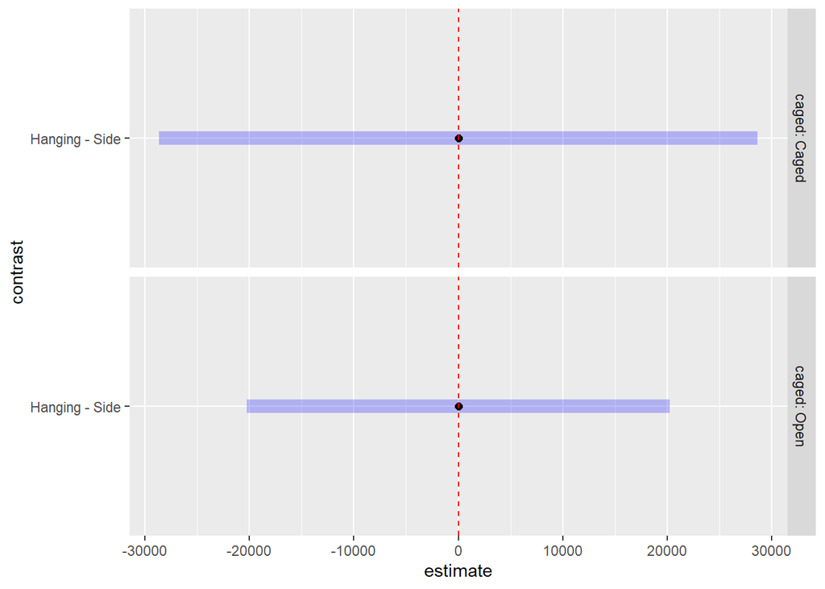

```r
# plot
cont <- contrast(emmeans(fouling_mle, ~ position_on_block|caged), method = "tukey")

plot(cont) +
  geom_vline(xintercept = 0, color = "red", lty = 2)
```

All tested assumptions for this model were not met. Means were homogeneous and residuals of change could not be identified.

**2.3** If you answered yes to the above…. you are wrong. It doesn’t! Percentage data is weird. Difference in percentages can be ever weirder! There are three tried and true solutions here. But they MIGHT not all work.

Incorporate initial cover as a covariate. This takes out that influence, and as such we’re looking at residuals of change. This sometimes, but not always, works.

```r
# Factorial Anova

# fit and assumption evaluation
fouling_mle <- glm(initial_cover ~ position_on_block*caged, data=fouling, family="gaussian")


#The whole par thing lets me make a multi-panel plot
par(mfrow=c(2,2))
plot(fouling_mle, which=c(1,2,5))
```

```
## hat values (leverages) are all = 0.125
##  and there are no factor predictors; no plot no. 5
```

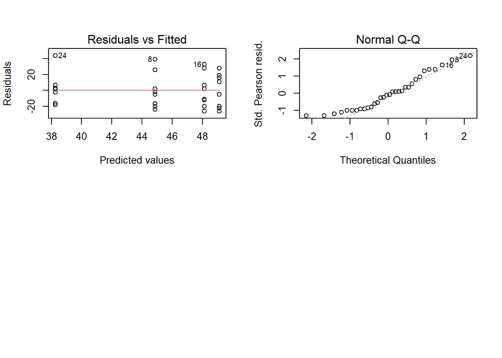

```r
par(mfrow=c(1,1))
```

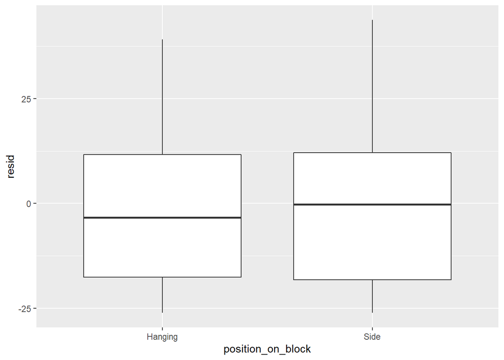

```r
# compare the distribution of residuals across each habitat
fouling <- fouling %>%
  add_residuals(fouling_mle)

qplot(position_on_block, resid, data = fouling, geom = "boxplot")
```

```r
# F-tests
Anova(fouling_mle)
```

```
## Analysis of Deviance Table (Type II tests)
##
## Response: initial_cover
##                         LR Chisq Df Pr(>Chisq)
## position_on_block        0.13871  1     0.7096
## caged                    0.87465  1     0.3497
## position_on_block:caged  0.25488  1     0.6137
```

```r
# compare means
fouling_mle_em <- emmeans(fouling_mle, ~position_on_block+caged)

multcomp::cld(fouling_mle_em)
```

```
##  position_on_block caged emmean   SE  df asymp.LCL asymp.UCL .group
##  Side              Caged   38.2 7.55 Inf      23.4      53.1  1
##  Hanging           Caged   44.9 7.55 Inf      30.1      59.7  1
##  Hanging           Open    48.1 7.55 Inf      33.3      62.9  1
##  Side              Open    49.1 7.55 Inf      34.3      63.9  1
##
## Confidence level used: 0.95
## P value adjustment: tukey method for comparing a family of 4 estimates
## significance level used: alpha = 0.05
```

```r
# posthocs
contrast(fouling_mle_em, method = "dunnett")
```

```
##  contrast                     estimate   SE  df z.ratio p.value
##  Side Caged - Hanging Caged      -6.62 10.7 Inf -0.620  0.8391
##  Hanging Open - Hanging Caged     3.25 10.7 Inf  0.304  0.9623
##  Side Open - Hanging Caged        4.25 10.7 Inf  0.398  0.9344
##
## P value adjustment: dunnettx method for 3 tests
```

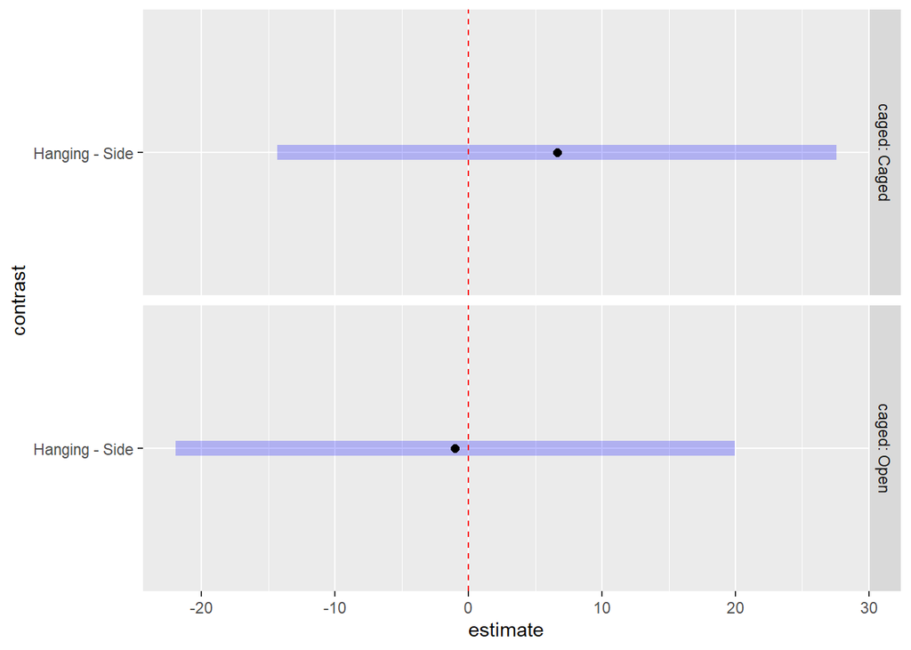

```r
# plot
cont <- contrast(emmeans(fouling_mle, ~ position_on_block|caged), method = "tukey")

plot(cont) +
  geom_vline(xintercept = 0, color = "red", lty = 2)
```

Divide change by initial cover to express change as percent change relative to initial cover.

```r
# add a column for percent change
fouling <-  fouling %>%
  mutate(percent_change = change_in_cover/initial_cover)

# Factorial Anova

# fit and assumption evaluation
fouling_mle <- glm(percent_change ~ position_on_block*caged, data=fouling, family="gaussian")


#The whole par thing lets me make a multi-panel plot
par(mfrow=c(2,2))
plot(fouling_mle, which=c(1,2,5))
```

```
## hat values (leverages) are all = 0.125
##  and there are no factor predictors; no plot no. 5
```

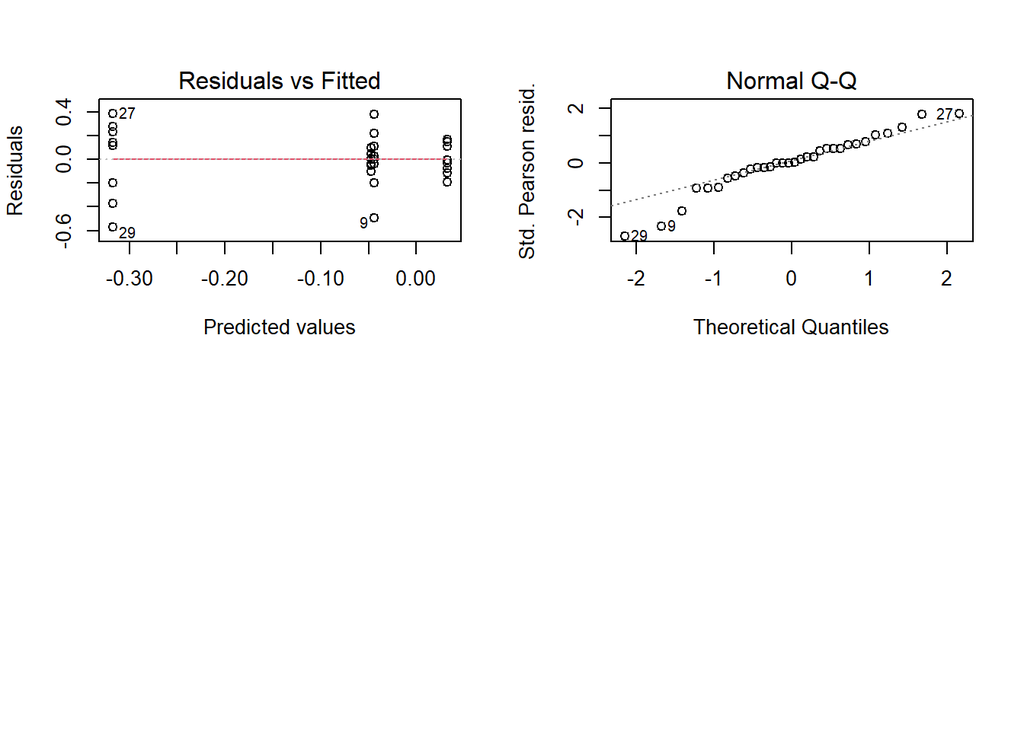

```r
par(mfrow=c(1,1))
```

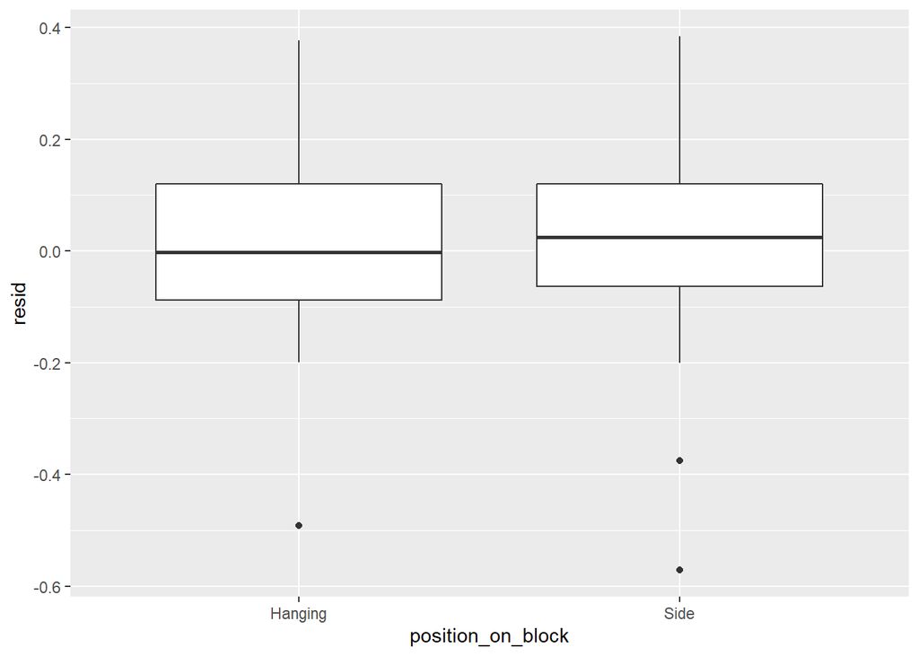

```r
# compare the distribution of residuals across each habitat
fouling <- fouling %>%
  add_residuals(fouling_mle)

qplot(position_on_block, resid, data = fouling, geom = "boxplot")
```

```r
# F-tests
Anova(fouling_mle)
```

```
## Analysis of Deviance Table (Type II tests)
##
## Response: percent_change
##                         LR Chisq Df Pr(>Chisq)
## position_on_block         4.8150  1    0.02821 *
## caged                     4.6258  1    0.03149 *
## position_on_block:caged   1.4525  1    0.22813
## ---
## Signif. codes:  0 '***' 0.001 '**' 0.01 '*' 0.05 '.' 0.1 ' ' 1
```

```r
# compare means
fouling_mle_em <- emmeans(fouling_mle, ~position_on_block+caged)

multcomp::cld(fouling_mle_em)
```

```
##  position_on_block caged  emmean     SE  df asymp.LCL asymp.UCL .group
##  Side              Open  -0.3173 0.0805 Inf    -0.475    -0.160  1
##  Side              Caged -0.0473 0.0805 Inf    -0.205     0.110  12
##  Hanging           Open  -0.0438 0.0805 Inf    -0.202     0.114  12
##  Hanging           Caged  0.0322 0.0805 Inf    -0.125     0.190   2
##
## Confidence level used: 0.95
## P value adjustment: tukey method for comparing a family of 4 estimates
## significance level used: alpha = 0.05
```

```r
# posthocs
contrast(fouling_mle_em, method = "dunnett")
```

```
##  contrast                     estimate    SE  df z.ratio p.value
##  Side Caged - Hanging Caged    -0.0796 0.114 Inf -0.699  0.7968
##  Hanging Open - Hanging Caged  -0.0761 0.114 Inf -0.669  0.8137
##  Side Open - Hanging Caged     -0.3496 0.114 Inf -3.072  0.0061
##
## P value adjustment: dunnettx method for 3 tests
```

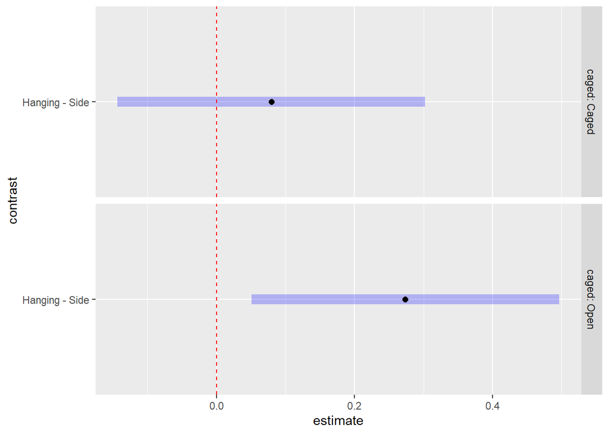

```r
# contrast means
cont <- contrast(emmeans(fouling_mle, ~ position_on_block|caged), method = "tukey")

# plot contrast
plot(cont) +
  geom_vline(xintercept = 0, color = "red", lty = 2)
```

Calculate difference in logit cover (so, logit(initial cover) - logit(final cover)). Logit transformations linearize percent cover data, and are often all that is needed to work percent cover into a linear model. You can use car::logit() for this.

```
## hat values (leverages) are all = 0.125
##  and there are no factor predictors; no plot no. 5
```

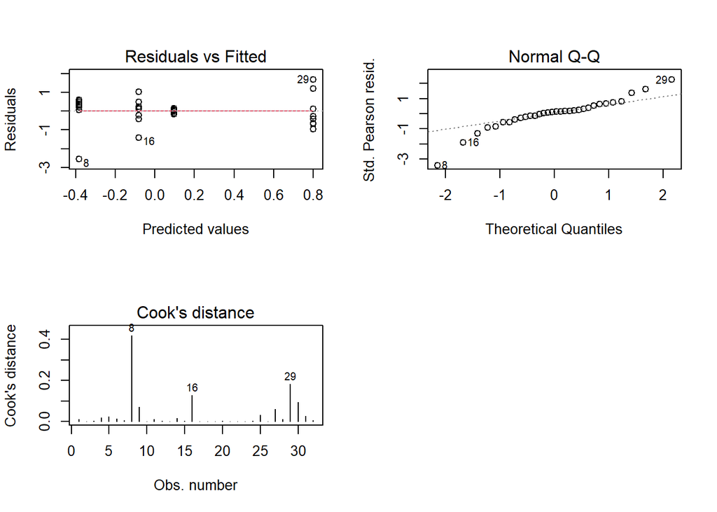

```r
#create a logit column
fouling <- fouling %>%
  mutate(Log = car::logit(initial_cover) - car::logit(final_cover))

# Factorial Anova

# fit and assumption evaluation
fouling_mle <- glm(Log ~ position_on_block*caged, data=fouling, family="gaussian")


#The whole par thing lets me make a multi-panel plot
par(mfrow=c(2,2))
plot(fouling_mle, which=c(1,2,4,5))
```

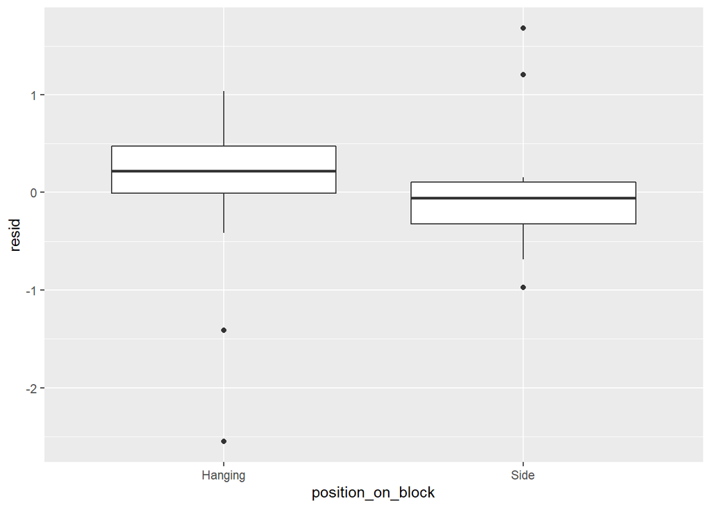

```r
par(mfrow=c(1,1))


# compare the distribution of residuals across each habitat
fouling <- fouling %>%
  add_residuals(fouling_mle)

qplot(position_on_block, resid, data = fouling, geom = "boxplot")
```

```r
# F-tests
Anova(fouling_mle)
```

```
## Analysis of Deviance Table (Type II tests)
##
## Response: Log
##                         LR Chisq Df Pr(>Chisq)
## position_on_block         5.8783  1    0.01533 *
## caged                     3.1975  1    0.07375 .
## position_on_block:caged   0.5070  1    0.47642
## ---
## Signif. codes:  0 '***' 0.001 '**' 0.01 '*' 0.05 '.' 0.1 ' ' 1
```

```r
# compare means
fouling_mle_em <- emmeans(fouling_mle, ~position_on_block+caged)

multcomp::cld(fouling_mle_em)
```

```
##  position_on_block caged  emmean    SE  df asymp.LCL asymp.UCL .group
##  Hanging           Caged -0.3853 0.282 Inf    -0.937     0.167  1
##  Hanging           Open  -0.0823 0.282 Inf    -0.634     0.470  12
##  Side              Caged  0.0969 0.282 Inf    -0.455     0.649  12
##  Side              Open   0.8008 0.282 Inf     0.249     1.353   2
##
## Confidence level used: 0.95
## P value adjustment: tukey method for comparing a family of 4 estimates
## significance level used: alpha = 0.05
```

```r
# posthocs
contrast(fouling_mle_em, method = "dunnett")
```

```
##  contrast                     estimate    SE  df z.ratio p.value
##  Side Caged - Hanging Caged      0.482 0.398 Inf 1.211   0.4765
##  Hanging Open - Hanging Caged    0.303 0.398 Inf 0.761   0.7615
##  Side Open - Hanging Caged       1.186 0.398 Inf 2.979   0.0083
##
## P value adjustment: dunnettx method for 3 tests
```

```r
# p-value correction
contrast(fouling_mle_em,
        method = "tukey", adjust="bonferroni")
```

```
##  contrast                     estimate    SE  df z.ratio p.value
##  Hanging Caged - Side Caged     -0.482 0.398 Inf -1.211  1.0000
##  Hanging Caged - Hanging Open   -0.303 0.398 Inf -0.761  1.0000
##  Hanging Caged - Side Open      -1.186 0.398 Inf -2.979  0.0174
##  Side Caged - Hanging Open       0.179 0.398 Inf  0.450  1.0000
##  Side Caged - Side Open         -0.704 0.398 Inf -1.768  0.4624
##  Hanging Open - Side Open       -0.883 0.398 Inf -2.218  0.1594
##
## P value adjustment: bonferroni method for 6 tests
```

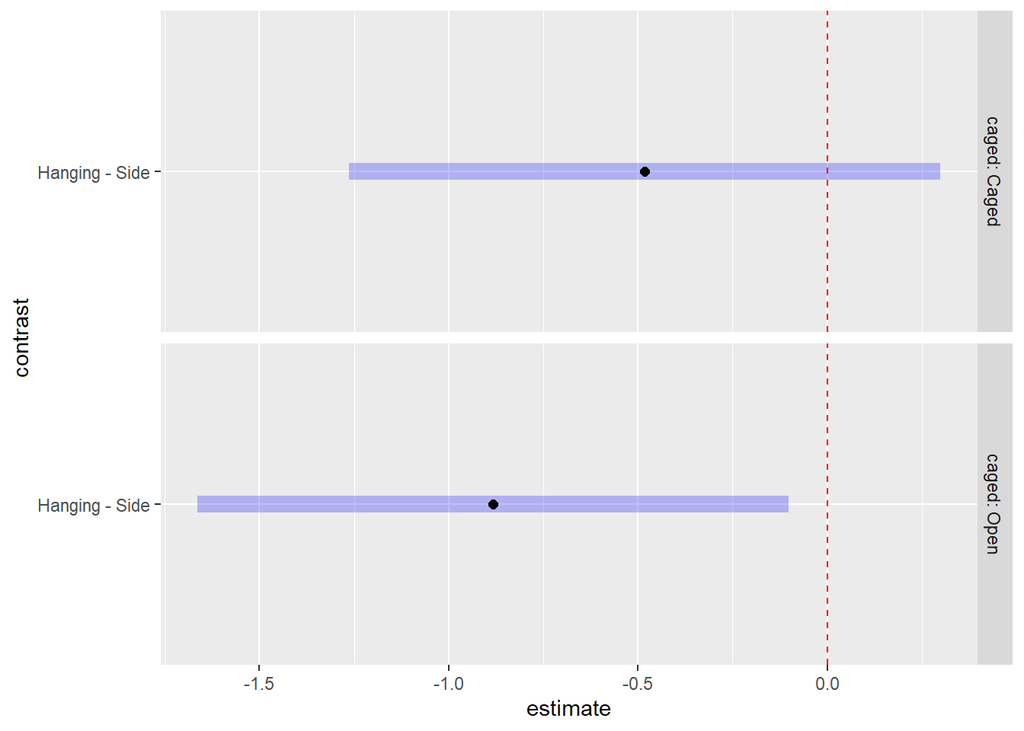

```r
# plot
cont <- contrast(emmeans(fouling_mle, ~ position_on_block|caged), method = "tukey")

plot(cont) +
  geom_vline(xintercept = 0, color = "red", lty = 2)
```

Try all three methods. Which one works so that you can produce valid inference?

**2.4** Great! So, take us home! Using NHST with an alpha of 0.08 (why not), what does this fit model tell you about whether predation matters given how I have described the system? Feel free to replot the data or fit model results if helpful.

**3. Comparing Means with Covariates**

We will wrap up with a model mixing continuous and discrete variables. In this dataset from Scantlebury *et al*, the authors explored how caste and mass affected the energy level of naked mole rats.